# Time series part 2

https://www.geeksforgeeks.org/machine-learning/time-series-analysis-and-forecasting/

time series plot means plotting data against time. for components of time series refe https://www.geeksforgeeks.org/data-science/components-of-time-series-data/

A seasonal pattern exists when a series is influenced by seasonal factors (e.g., the quarter of the year, the month, or day of the week). Seasonality is always of a fixed and known period. Hence, seasonal time series are sometimes called periodic time series.

A cyclic pattern exists when data exhibit rises and falls that are not of fixed period.

**Linear filtering** is the process of transforming a time series into another time series by taking **linear combinations of its current and past values**. Mathematically, a linear filter can be written as:

$$y_t=\sum_{k=-\infty}^\infty a_k x_{t-k}$$

| Purpose | Filter Type | Description |
| --- | --- | --- |
| **Smoothing** | Moving average | Reduces random noise to show underlying trend |
| **Detrending** | Differencing | Removes trend (acts as a high-pass filter) |
| **Seasonal adjustment** | Seasonal difference | Removes repeating seasonal patterns |
| **Lag operator** | AR/MA models | Represented as filters that depend on lagged terms |

## Time series smoothing

simple moving average SMA= sum of last n values / n

“Imagine you track your daily step count. Some days you walk 12,000 steps, others only 3,000. It jumps up and down — hard to see the pattern. But if you take the average of the last 7 days every day, the number changes more smoothly — that’s a 7-day moving average!”

“Imagine you’re walking uphill — your altitude keeps rising. Instead of tracking your altitude, what if you record how much you moved up or down each step? The resulting values might fluctuate around zero — that’s differencing.”

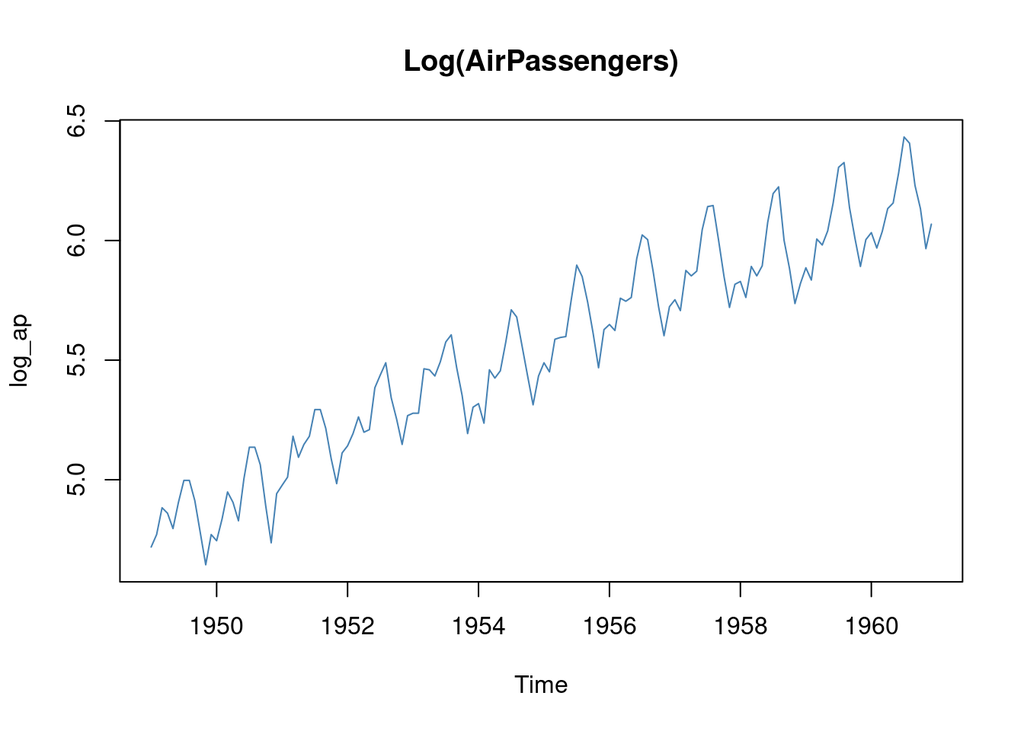

```r
log_ap <- log(AirPassengers)
plot(log_ap, main="Log(AirPassengers)", col="steelblue")
```

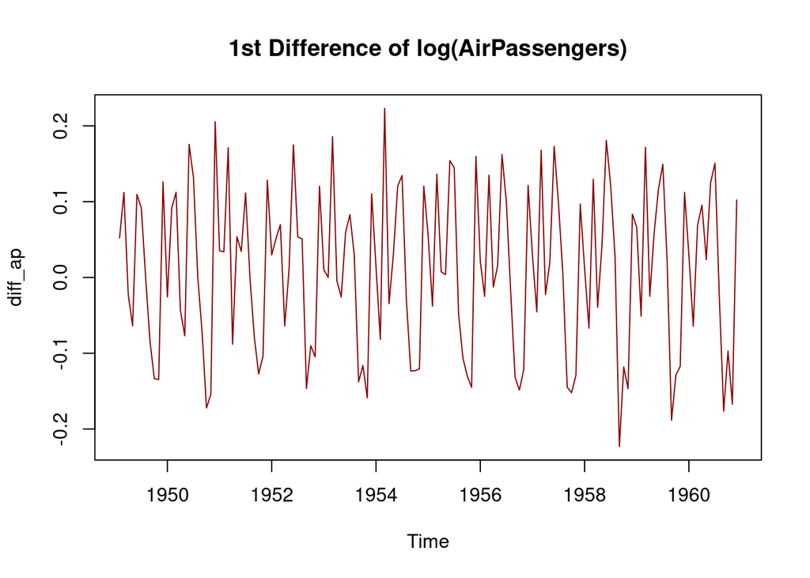

```r
diff_ap <- diff(log_ap,1)
plot(diff_ap, main = "1st Difference of log(AirPassengers)", col = "darkred")
```

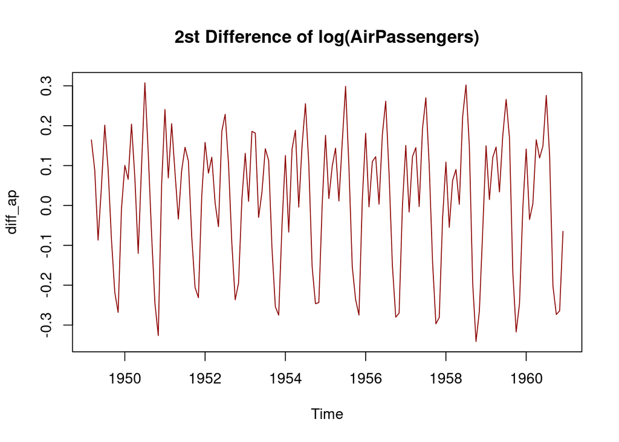

```r
diff_ap <- diff(log_ap,2)
plot(diff_ap, main = "2st Difference of log(AirPassengers)", col = "darkred")
```

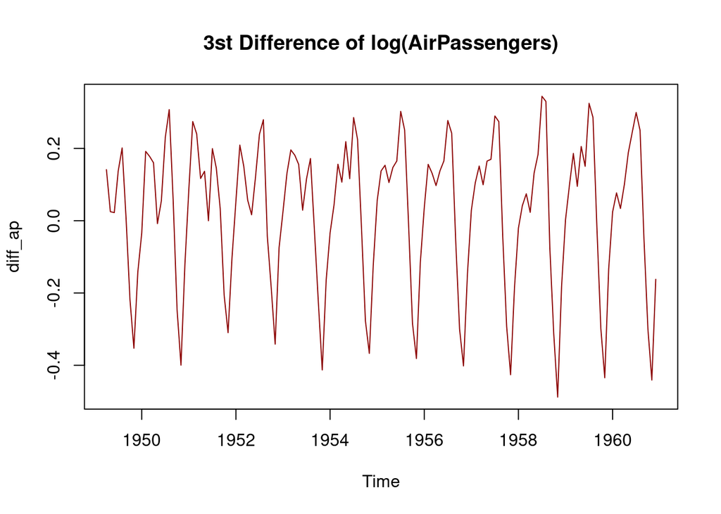

```r
diff_ap <- diff(log_ap,3)
plot(diff_ap, main = "3st Difference of log(AirPassengers)", col = "darkred")
```

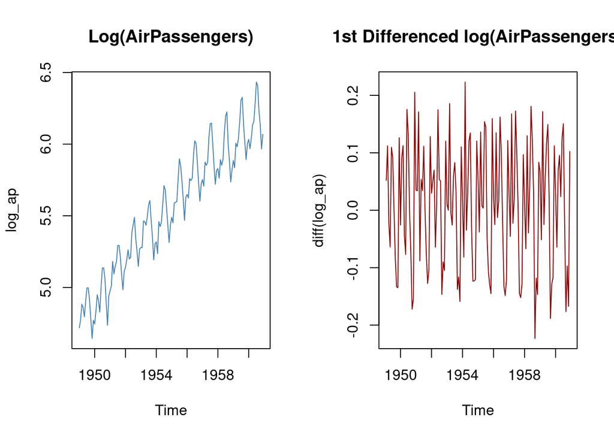

```r
par(mfrow=c(1,2))
plot(log_ap, main="Log(AirPassengers)", col="steelblue")
plot(diff(log_ap), main="1st Differenced log(AirPassengers)", col="darkred")
```

```r
par(mfrow=c(1,1))
```

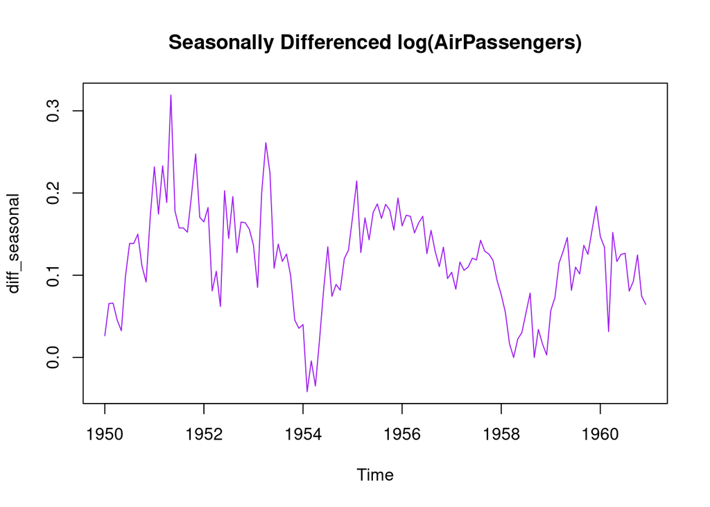

```r
diff_seasonal <- diff(log_ap, lag = 12)
plot(diff_seasonal, main = "Seasonally Differenced log(AirPassengers)", col = "purple")
```

Additive seasonality occurs when the magnitude of seasonal fluctuations is relatively constant over time, like a steady up-and-down pattern. Multiplicative seasonality occurs when the magnitude of seasonal fluctuations increases or decreases proportionally with the trend of the data, meaning the peaks and troughs get wider or narrower as the overall level of the series changes

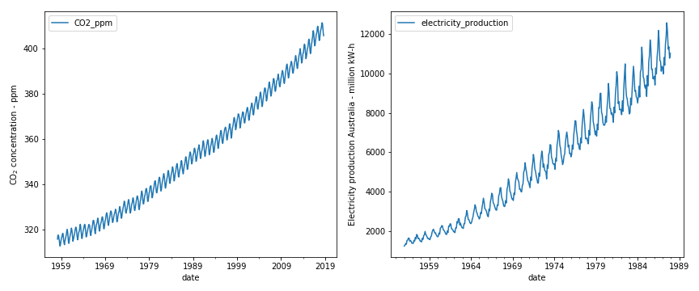

In an **additive model**, the observed value is the sum of trend, seasonality, and residual components: **Y(t) = Trend(t) + Seasonality(t) + Residual(t)**.

A **multiplicative model** represents the observed value as the product of its components: **Y(t) = Trend(t) * Seasonality(t) * Residual(t)**.

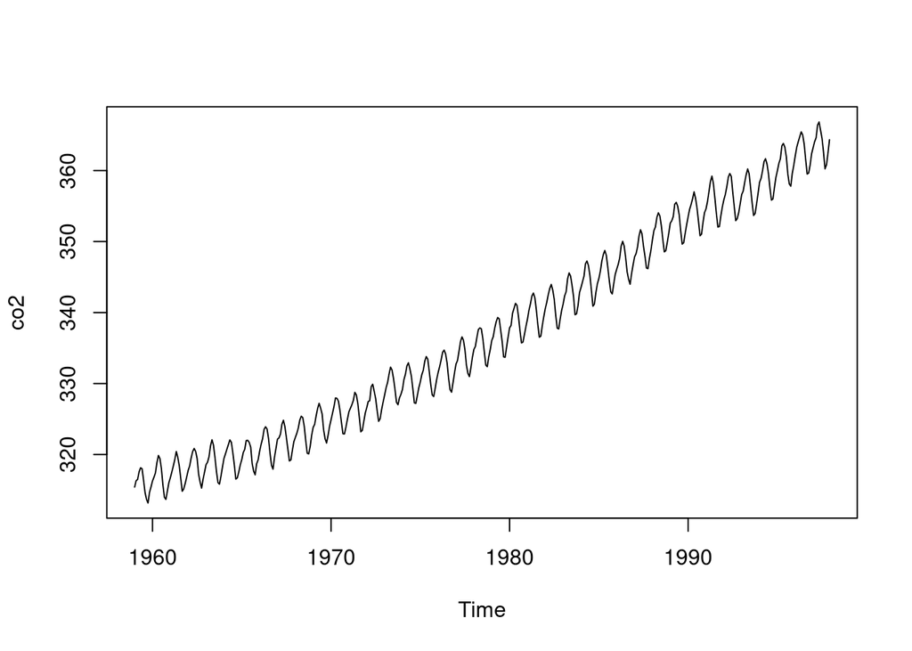

```r
data("co2")
plot(co2)
```

```r
decompose_co2<-decompose(co2)
print(decompose_co2)
```

```
## $x
##         Jan    Feb    Mar    Apr    May    Jun    Jul    Aug    Sep    Oct
## 1959 315.42 316.31 316.50 317.56 318.13 318.00 316.39 314.65 313.68 313.18
## 1960 316.27 316.81 317.42 318.87 319.87 319.43 318.01 315.74 314.00 313.68
## 1961 316.73 317.54 318.38 319.31 320.42 319.61 318.42 316.63 314.83 315.16
## 1962 317.78 318.40 319.53 320.42 320.85 320.45 319.45 317.25 316.11 315.27
## 1963 318.58 318.92 319.70 321.22 322.08 321.31 319.58 317.61 316.05 315.83
## 1964 319.41 320.07 320.74 321.40 322.06 321.73 320.27 318.54 316.54 316.71
## 1965 319.27 320.28 320.73 321.97 322.00 321.71 321.05 318.71 317.66 317.14
## 1966 320.46 321.43 322.23 323.54 323.91 323.59 322.24 320.20 318.48 317.94
## 1967 322.17 322.34 322.88 324.25 324.83 323.93 322.38 320.76 319.10 319.24
## 1968 322.40 322.99 323.73 324.86 325.40 325.20 323.98 321.95 320.18 320.09
## 1969 323.83 324.26 325.47 326.50 327.21 326.54 325.72 323.50 322.22 321.62
## 1970 324.89 325.82 326.77 327.97 327.91 327.50 326.18 324.53 322.93 322.90
## 1971 326.01 326.51 327.01 327.62 328.76 328.40 327.20 325.27 323.20 323.40
```

[output cut: 362 more lines]

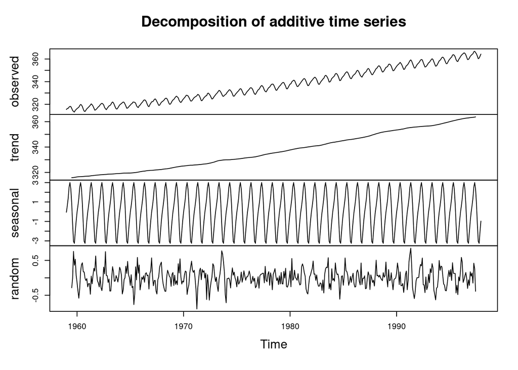

```r
plot(decompose_co2)
```

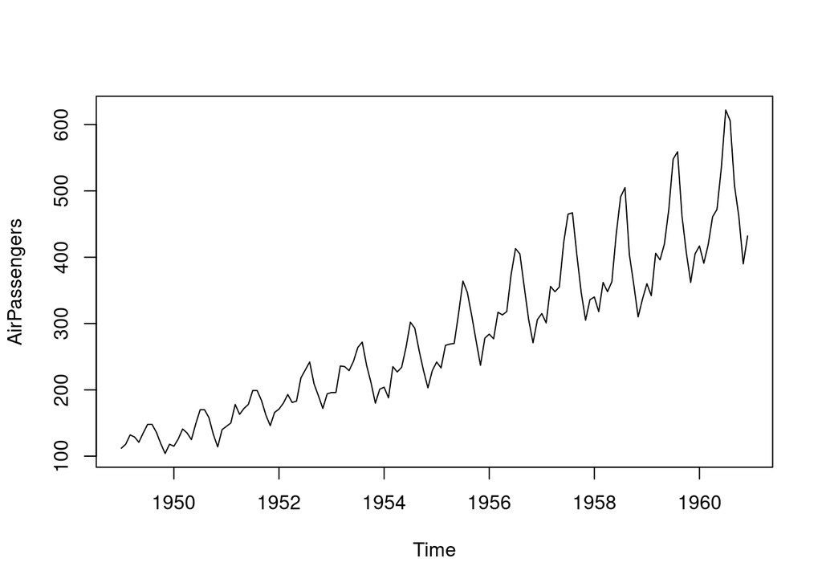

```r
data("AirPassengers")
plot(AirPassengers)
```

```r
decompose_airpass<-decompose(AirPassengers, type="multiplicative")
print(decompose_airpass)
```

```
## $x
##      Jan Feb Mar Apr May Jun Jul Aug Sep Oct Nov Dec
## 1949 112 118 132 129 121 135 148 148 136 119 104 118
## 1950 115 126 141 135 125 149 170 170 158 133 114 140
## 1951 145 150 178 163 172 178 199 199 184 162 146 166
## 1952 171 180 193 181 183 218 230 242 209 191 172 194
## 1953 196 196 236 235 229 243 264 272 237 211 180 201
## 1954 204 188 235 227 234 264 302 293 259 229 203 229
## 1955 242 233 267 269 270 315 364 347 312 274 237 278
## 1956 284 277 317 313 318 374 413 405 355 306 271 306
## 1957 315 301 356 348 355 422 465 467 404 347 305 336
## 1958 340 318 362 348 363 435 491 505 404 359 310 337
## 1959 360 342 406 396 420 472 548 559 463 407 362 405
## 1960 417 391 419 461 472 535 622 606 508 461 390 432
##
```

[output cut: 93 more lines]

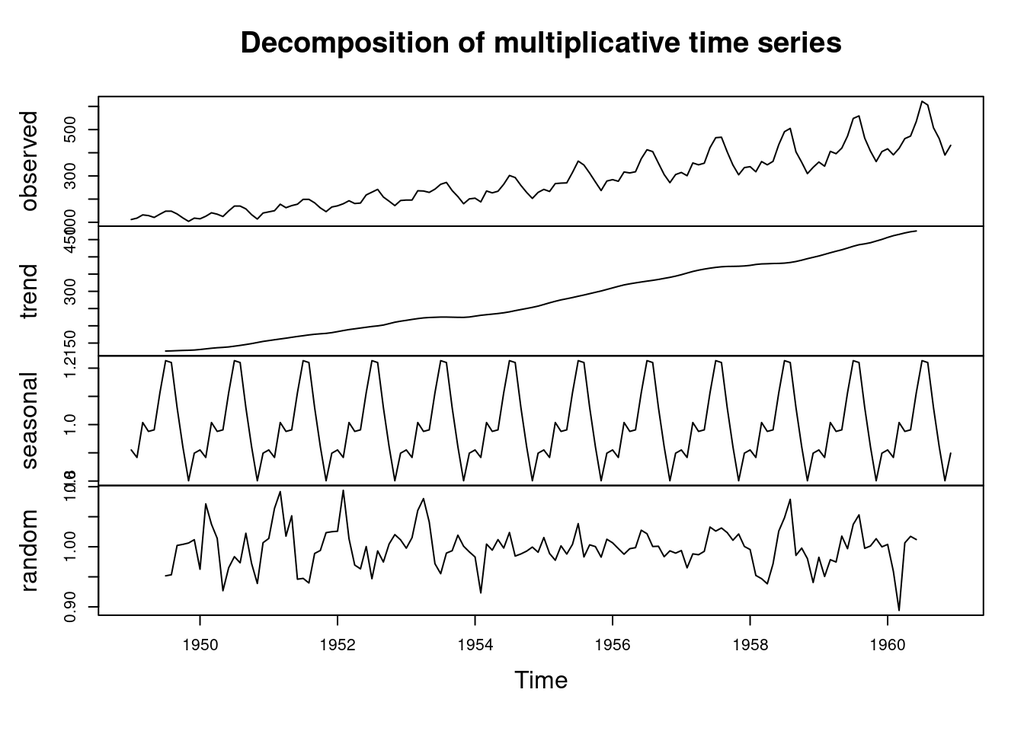

```r
plot(decompose_airpass)
```

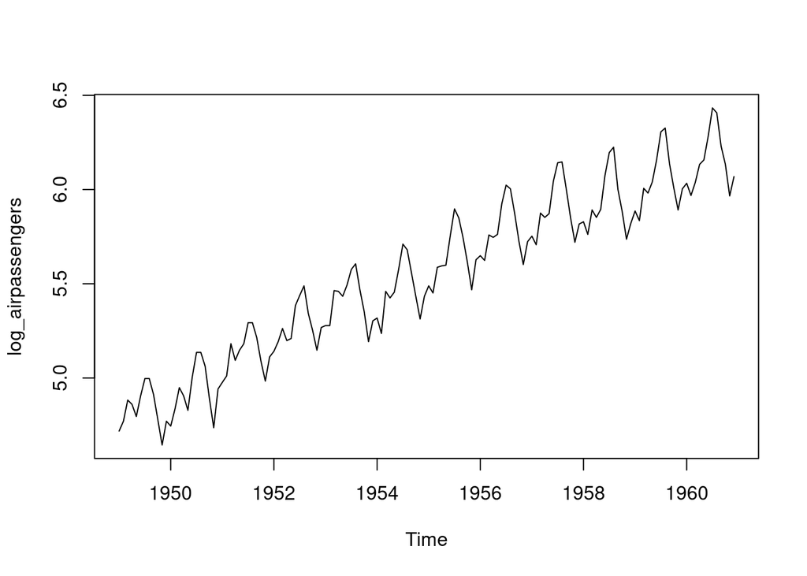

```r
log_airpassengers<-log(AirPassengers)
plot(log_airpassengers)
```

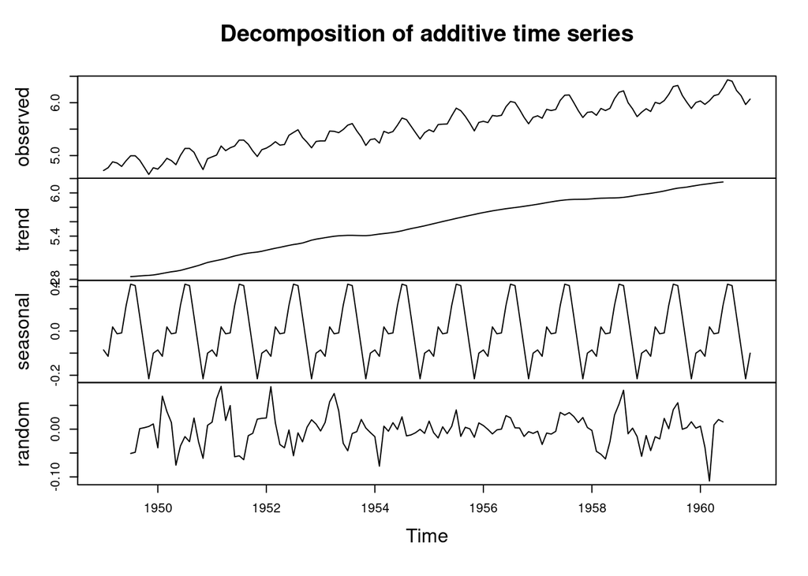

```r
dec_log_air<-decompose(log_airpassengers)
plot(dec_log_air)
```

**STL** stands for **Seasonal-Trend decomposition using Loess**.

It’s a **flexible, nonparametric** method that works especially well for data with:**nonlinear trends**, and **changing seasonality**.It’s available in base R — no extra package required!

https://www.datascienceinstitute.net/ai-data-science-blog/time-series-decomposition-in-r

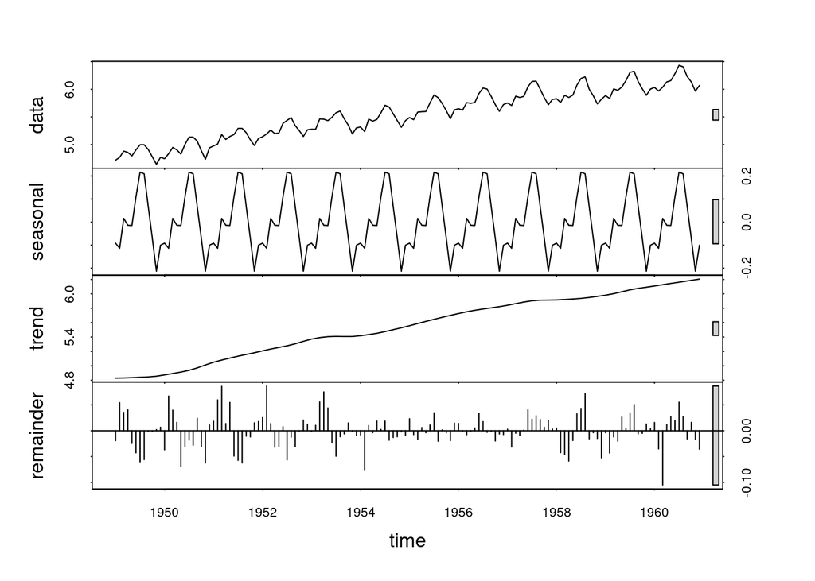

```r
log_ap <- log(AirPassengers)
stl_ap <- stl(log_ap, s.window = "periodic")
# periodic means constant season
plot(stl_ap)
```

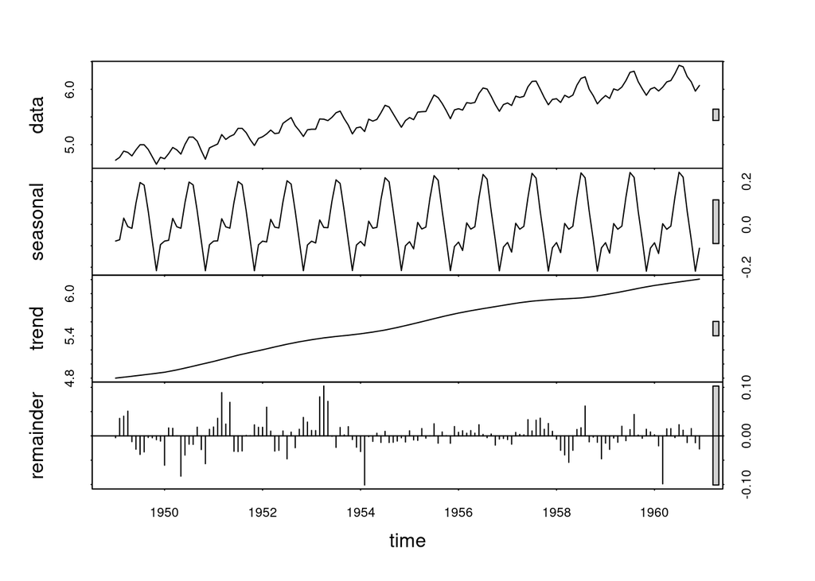

```r
stl_ap2 <- stl(log_ap, s.window = 13, t.window = 25, robust = TRUE)
plot(stl_ap2)
```

```r
library(forecast)
```

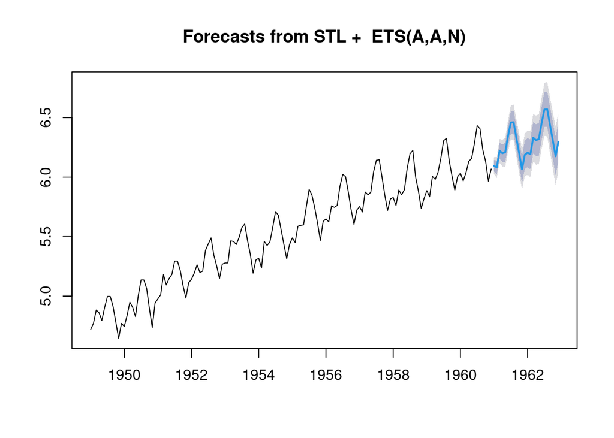

```r
fit <- stl(log_ap, s.window="periodic")
fcast <- forecast(fit)
plot(fcast)
```

## The Intuitive Meaning of “Level”

The **level** of a time series is simply its **baseline value** — the underlying “average” around which the data fluctuates at a given point in time.

Think of it as the **current overall position or height** of the series, ignoring trend or seasonality.

### Analogy:

Imagine a tide on the beach:

The **waves** going up and down = **seasonality**

- The **slowly rising sea** due to climate = **trend**

  The **current waterline right now** = **level**
- So, the **level** is the “center” or “baseline” value of the time series at time *t*.

  https://byjus.com/maths/exponential-smoothing/

**Holt–Winters Exponential Smoothing**

- **Simple Exponential Smoothing (SES)** → handles *level* (no trend or seasonality)
- **Holt’s Linear Method** → handles *level + trend*
- **Holt–Winters Method** → handles *level + trend + seasonality*

So **Winter’s smoothing** is the natural next step — it extends exponential smoothing to include *seasonal effects* in addition to trend and level.

“Winter’s method continuously updates estimates of three components:

the **current level** (ℓₜ), the **trend or growth rate** (bₜ), and the **seasonal pattern** (sₜ).”

[output not shown]

| Method | Captures Level | Captures Trend | Captures Seasonality | R Function |
| --- | --- | --- | --- | --- |
| Simple Exponential Smoothing | ✅ | ❌ | ❌ | `HoltWinters(y, beta=FALSE, gamma=FALSE)` |
| Holt’s Linear Method | ✅ | ✅ | ❌ | `HoltWinters(y, gamma=FALSE)` |
| Holt–Winters | ✅ | ✅ | ✅ | `HoltWinters(y)` |

### Errors should be random (no patterns), symmetric and consistent

ACF (auto correlation function) plot

- auto indicates itself
- Errors should be random (no patterns)
- Errors should be symmetric (Around 0) histogram should be more at 0 (mean and median is zero)
- Error should be same size over time (plot errors over time) fennel effet errors are gradually increasing

– step change =sudden change in error rate.

https://rstudio-pubs-static.s3.amazonaws.com/311446_08b00d63cc794e158b1f4763eb70d43a.html

```r
attend=c(45,56,60,35,55,48,49,30,58,41,56,45,34,60,54,44, 56, 57, 31, 56,45,34,58,59,47,48,35,41,58)
writeLines(paste(attend),"Attendance.txt")
a<-scan("Attendance.txt")

a
```

```
##  [1] 45 56 60 35 55 48 49 30 58 41 56 45 34 60 54 44 56 57 31 56 45 34 58 59 47
## [26] 48 35 41 58
```

```r
t<-ts(a)

t
```

```
## Time Series:
## Start = 1
## End = 29
## Frequency = 1
##  [1] 45 56 60 35 55 48 49 30 58 41 56 45 34 60 54 44 56 57 31 56 45 34 58 59 47
## [26] 48 35 41 58
```

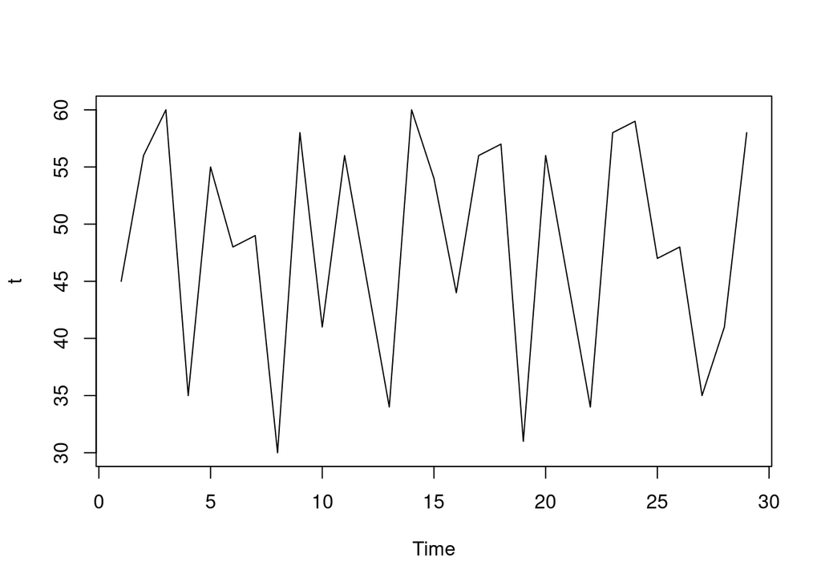

```r
plot(t)
```

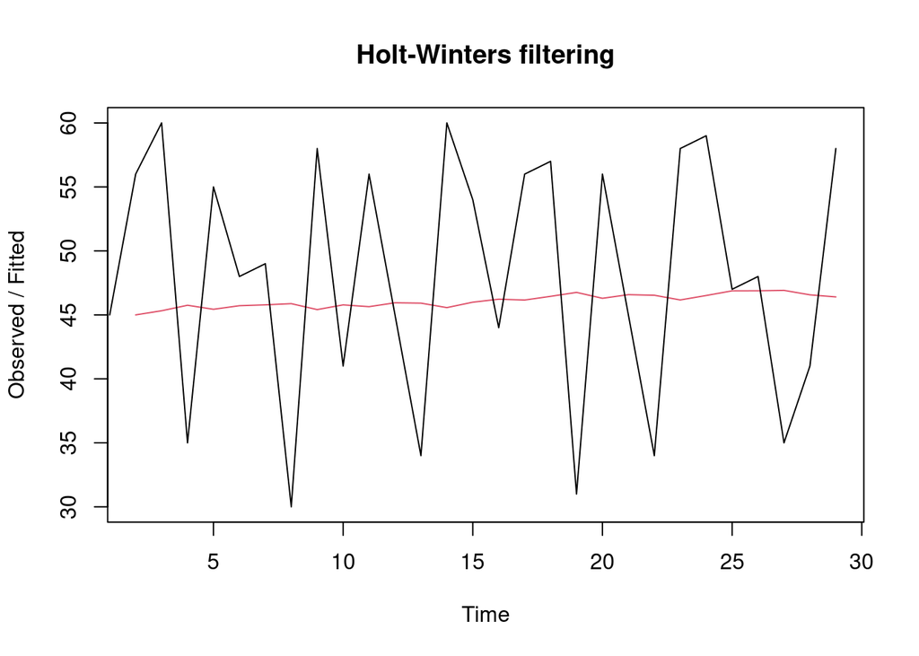

```r
# now we use simple exponential smoothing
h<-HoltWinters(t,beta=FALSE,gamma=FALSE)
plot(h)
```

```r
h
```

```
## Holt-Winters exponential smoothing without trend and without seasonal component.
##
## Call:
## HoltWinters(x = t, beta = FALSE, gamma = FALSE)
##
## Smoothing parameters:
##  alpha: 0.02928715
##  beta : FALSE
##  gamma: FALSE
##
## Coefficients:
##       [,1]
## a 46.74314
```

```r
# we are using holt exxponentila smoothing
h<-HoltWinters(t,gamma=FALSE)
h
```

```
## Holt-Winters exponential smoothing with trend and without seasonal component.
##
## Call:
## HoltWinters(x = t, gamma = FALSE)
##
## Smoothing parameters:
##  alpha: 0.4091399
##  beta : 0.4093066
##  gamma: FALSE
##
## Coefficients:
##         [,1]
## a 46.9574567
## b  0.6991394
```

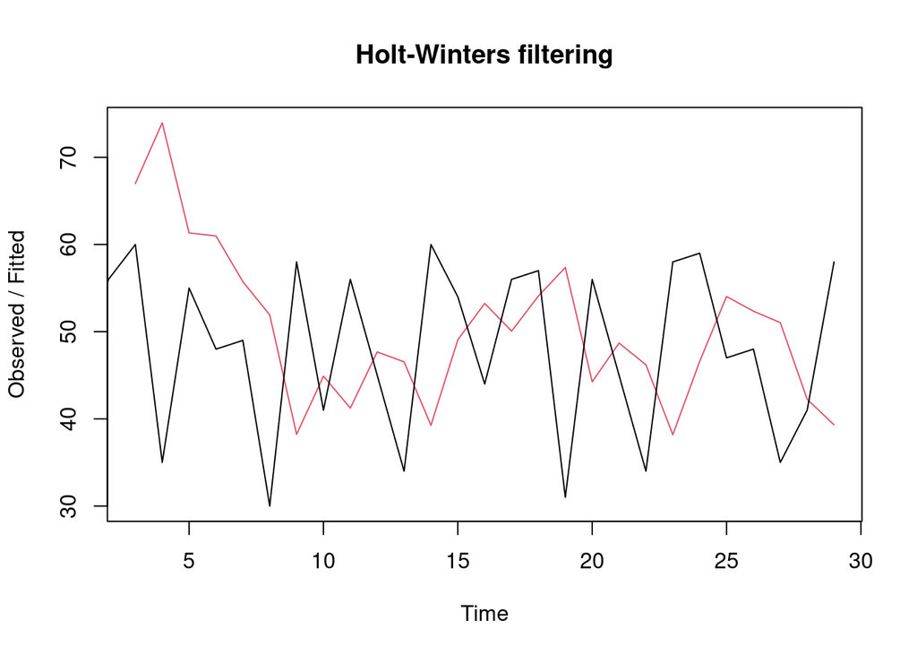

```r
plot(h)
```

```r
t<-ts(a,frequency = 12)
h<-HoltWinters(t)
#Holt-Winters exponential smoothing with trend and additive seasonality
h
```

```
## Holt-Winters exponential smoothing with trend and additive seasonal component.
##
## Call:
## HoltWinters(x = t)
##
## Smoothing parameters:
##  alpha: 0
##  beta : 0
##  gamma: 0
##
## Coefficients:
##            [,1]
## a    48.7596639
## b     0.0789627
## s1    7.8472222
## s2    0.5555556
## s3  -18.1527778
## s4    9.9305556
## s5   -7.1944444
## s6    7.3888889
## s7   -4.0277778
## s8  -14.6527778
## s9   11.0138889
## s10   4.4722222
## s11  -4.6944444
## s12   7.5138889
```

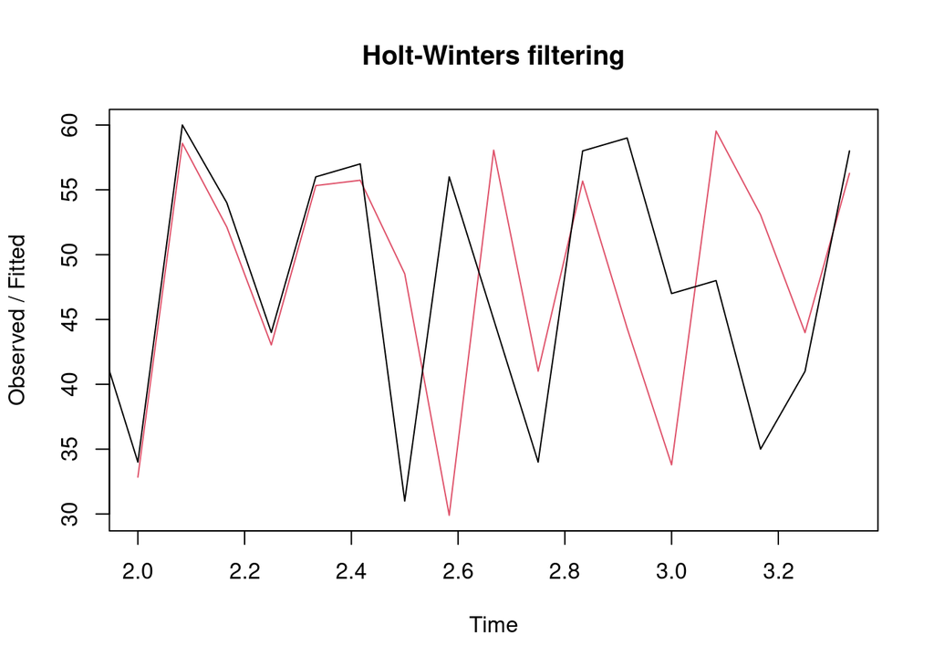

```r
plot(h)
```

## Similarity Search in Time-Series Data

To measure how *similar* or *different* two time series are — even if they vary in speed or timing.

### Example

Imagine two people walking along the same route:

Person A walks steadily.

Person B walks slowly at first and faster later.

Their *paths* (shapes of their time series) are the same, but their *timing* differs.  
https://www.geeksforgeeks.org/machine-learning/similarity-search-for-time-series-data/

Traditional distance metrics like **Euclidean distance** would say they’re different because it compares point-to-point in time.

**DTW (Dynamic Time Warping)** solves this.

Dynamic Time Warping allows **non-linear alignment** between two time series.

It “warps” (stretches or compresses) the time axis to find the best possible match. So instead of comparing each time point $t_1$, $t_2$, $t_3$, … directly, DTW aligns them flexibly.